# Vor lauter Cohen das d nicht sehen.

28. Juni 2022

## Background & Focus

### Why looking at effect sizes?

- There exist several “clearing house” approaches  
  “best available […] evidence from systematic research” (Sackett et al., 1996, p. 71)
- particularly evaluated according to the extent to which it allows to assess treatment effectiveness, i.e. the investigation of whether a treatment works (APA, 2002)
- Meta-analyses (research syntheses) = highest level of evidence  
  ES = key information to be communicated (Burns et al., 2011)

## Background & Focus

### Why looking at visualizations?

- scientists & clearing houses typically use standardized **textual** representations (Cohen, 1988)
- textual representations of effect sizes are **challenging** for teachers’ perception and understanding (Hanel & Mehler, 2019; Lortie-Forgues et al., 2021)
- Alternative: visualizations (Franconeri et al., 2021)

## Background & Focus

### Design, perception & use of visualizing ES

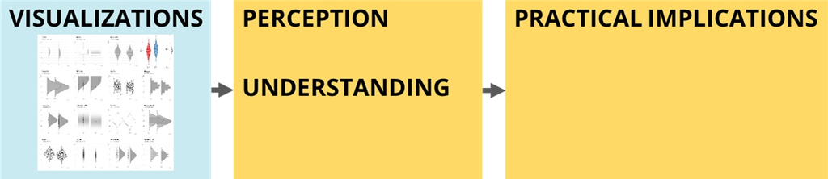

(Brown et al., 2017)

## Background & Focus

### Design, perception & use of visualizing ES

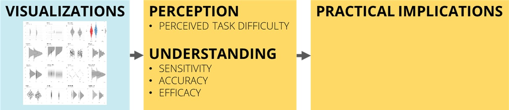

(Korbach et al., 2017; McPhetres & Pennycook, 2020)

## Background & Focus

### Design, perception & use of visualizing ES

(Lortie-Forgues et al., 2021)

## Background & Focus

### What we know about visualizing data (in general)

## Background & Focus

### What we know about visualizing data (for lay people)

accurate estimation of statistical information needed for the evaluation of effect sizes: Type of visualization plays a role

- box plots: spread; distribution
- bar/line plot: mean
- modified stock chart: maxima, minima; spread

(Albers et al., 2014; Pierce & Chick, 2013)

## Objectives & Reserach Questions

### Exploratory & descriptive: Visualization types

1. Does **visualization type** affect A, B, C in assessing effect sizes?
2. Which visualization types produce the **highest ratings** in A, B, C?

## Objectives & Reserach Questions

### Exploratory & descriptive: Enrichment options

1. Does **visualization type** affect A, B, C in assessing effect sizes?
2. Which visualization types produce the **highest ratings** in A, B, C?
3. How do visualizations with **visual benchmarks** affect A, B, C, compared to visualizations without benchmarks?
4. How do visualizations with **textual cues** affect A, B, C compared to visualizations without textual cues and a control group?

## Methods

## Pilot Study

**Delphi Study**

- **4 Experts** in Data Visualization, **4 Experts** in Science Communication
- Phase 1: Collecting **16 visualization types**  
  (for group scores on a metric variable)

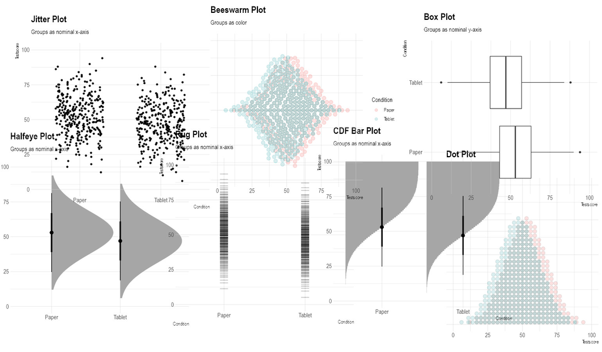

## Pilot Study

**Delphi Study**

- **4 Experts** in Data Visualization, **4 Experts** in Science Communication
- Phase 1: Collecting **16 visualization types**  
  (for group scores on a metric variable)
- Phase 2: Rating and Ranking of **44 visualizations**

*“How accurately might teachers assess the effect size depicted in the plot above?”*  
(7-stufige Likert Skala; totally random - totally accurate)

## Pilot Study

**Delphi Study**

- **4 Experts** in Data Visualization, **4 Experts** in Science Communication
- Phase 1: Collecting **16 visualization types**  
  (for group scores on a metric variable)
- Phase 2: Rating and Ranking of **44 Visualizations**

*“How accurately might teachers assess the effect size depicted in the plot above?”*  
(7-stufige Likert Skala; totally random - totally accurate)

**Results: Top ranked types**

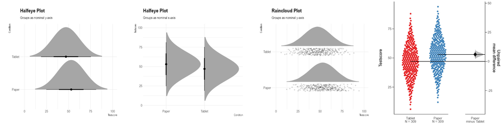

## Study 1

### Visualization types: Design

- student teachers (N = Bayesian updating)
- 4 x 6 within-design
  - 4 visualization types
  - 6 effect sizes
- randomizations
  - order of conditions
  - vignettes (1 of 4 randomized between)

## Study 1

### Visualization types: Measures

- Perceived task difficulty (Marcus et al., 1996)
- Sensitivity (Merk et al., under review)
- Accuracy
- Efficiency
- Perceived informativeness (Lortie-Forgues et al., 2021;  
  Hanel & Mehler, 2019)
- Perceived value
- Intention to use

Demo: es-vis-demo.formr.org

## Study 1

### Visualization types: Statistical Analyses

1. Does **visualization type** affect A, B, C in assessing effect sizes?  
   testing intraclass correlations against 0
2. Which visualization types produce the **highest ratings**?  
   descriptive and graphical analyses

## Study 2

### Enrichment options: Design

- student teachers (N = Bayesian updating)
- 2 RCTs
  - Factor: visual benchmarking (yes vs. no)
  - Factor: textual cues (Vis+Text, VisOnly, TextOnly)

## Study 2

### Enrichment options: Design

- student teachers (N = Bayesian updating)
- 2 RCTs
  - Factor: visual benchmarking (yes vs. no)
  - Factor: textual cues (Vis+Text, VisOnly, TextOnly)

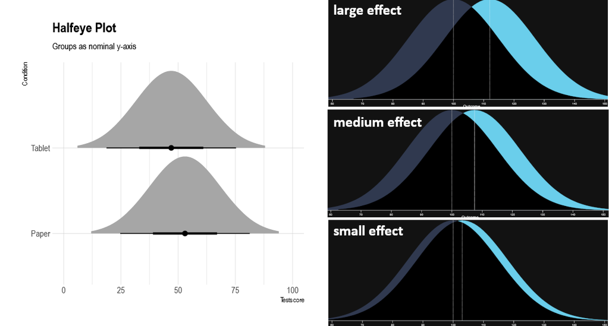

## Study 2

### Enrichment options: Design

- student teachers (N = Bayesian updating)
- 2 RCTs
  - Factor: visual benchmarking (yes vs. no)
  - Factor: textual cues (Vis+Text, VisOnly, TextOnly)

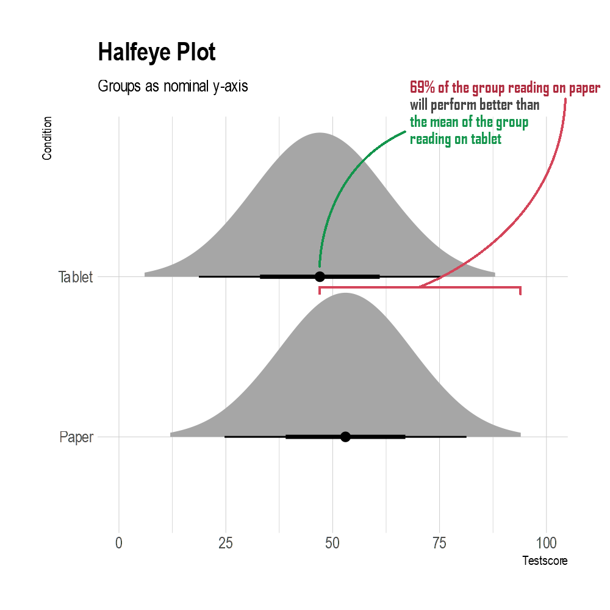

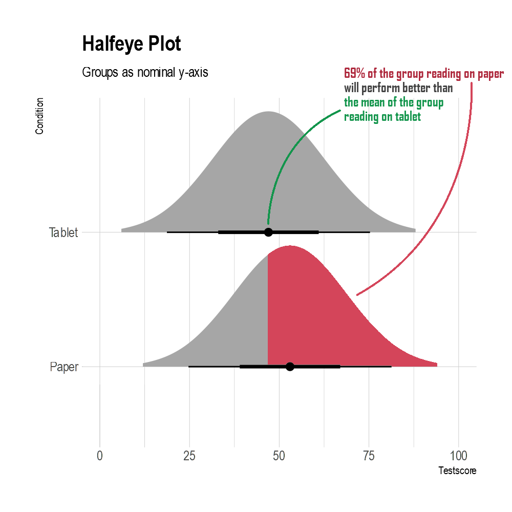

## Study 2

### Enrichment options: Design

- student teachers (N = Bayesian updating)
- 2 RCTs
  - Factor: visual benchmarking (yes vs. no)
  - Factor: textual cues (Vis+Text, VisOnly, TextOnly)
- randomizations
  - size of effect (d= -.8 to .8)
  - order of conditions
  - vignettes (1 of 4 randomized between)

## Study 2

### Visualization types: Measures

See Study 1

## Study 2

### Statistical Analyses

- approximate adjusted fractional Bayes factors (Hoijtink et al., 2019)

**Benchmarking**

H3.1: \(\mu(sens)_{noBench} < \mu(sens)_{Bench}\)

H3.2: \(\mu(acc)_{noBench} < \mu(acc)_{Bench}\)

H3.3: \(\mu(inf)_{noBench} < \mu(inf)_{Bench}\)

H3.4: \(\mu(diff)_{noBench} > \mu(diff)_{Bench}\)

## Study 2

### Statistical Analyses

- approximate adjusted fractional Bayes factors (Hoijtink et al., 2019)

**Textual Cues**

H4.1: \((\mu(sens)_{VisOnly} , \mu(sens)_{TextOnly}) < \mu(sens)_{Vis+Text}\)

H4.2: \((\mu(acc)_{VisOnly} , \mu(acc)_{TextOnly}) < \mu(acc)_{Vis+Text}\)

H4.3: \((\mu(inf)_{VisOnly} , \mu(inf)_{TextOnly}) < \mu(inf)_{Vis+Text}\)

H4.4: \((\mu(diff)_{VisOnly} , \mu(diff)_{TextOnly}) > \mu(diff)_{Vis+Text}\)

## Current progress

## Current progress

- Pilot study completed
- Abstract for Registered Report will be sumbitted tomorrow
- Next: Piloting of self-generated measures

## Vielen Dank

**Jürgen Schneider**  
juergen.schneider@uni-tuebingen.de

Albers, D., Correll, M., & Gleicher, M. (2014). Task-driven evaluation of aggregation in time series visualization. *Proceedings of the SIGCHI Conference on Human Factors in Computing Systems*, 551–560. https://doi.org/10.1145/2556288.2557200

APA. (2002). Criteria for evaluating treatment guidelines. *American Psychologist*, *57*(12), 1052–1059. https://doi.org/10.1037/0003-066X.57.12.1052

Brown, C., Schildkamp, K., & Hubers, M. D. (2017). Combining the best of two worlds: A conceptual proposal for evidence-informed school improvement. *Educational Research*, *59*(2), 154–172. https://doi.org/10.1080/00131881.2017.1304327

Burns, P. B., Rohrich, R. J., & Chung, K. C. (2011). The levels of evidence and their role in evidence-based medicine. *Plastic and Reconstructive Surgery*, *128*(1), 305–310. https://doi.org/10.1097/PRS.0b013e318219c171

Cohen, J. (1988). *Statistical Power Analysis for the Behavioral Sciences* (2nd ed.). Taylor and Francis.

Farley-Ripple, E. N., Oliver, K., & Boaz, A. (2020). Mapping the community: Use of research evidence in policy and practice. *Humanities and Social Sciences Communications*, *7*(1), 83. https://doi.org/10.1057/s41599-020-00571-2

Franconeri, S. L., Padilla, L. M., Shah, P., Zacks, J. M., & Hullman, J. (2021). The Science of Visual Data Communication: What Works. *Psychological Science in the Public Interest*, *22*(3), 110–161. https://doi.org/10.1177/15291006211051956

Hanel, P. H. P., & Mehler, D. M. (2019). Beyond reporting statistical significance: Identifying informative effect sizes to improve scientific communication. *Public Understanding of Science*, *28*(4), 468–485. https://doi.org/10.1177/0963662519834193

Hedges, L. V. (2018). Challenges in Building Usable Knowledge in Education. *Journal of Research on Educational Effectiveness*, *11*(1), 1–21. https://doi.org/10.1080/19345747.2017.1375583

Hoijtink, H., Gu, X., Mulder, J., & Rosseel, Y. (2019). Computing Bayes factors from data with missing values. *Psychological Methods*, *24*(2), 253–268. https://doi.org/10.1037/met0000187

Korbach, A., Brünken, R., & Park, B. (2017). Measurement of cognitive load in multimedia learning: A comparison of different objective measures. *Instructional Science*, *45*(4), 515–536. https://doi.org/10.1007/s11251-017-9413-5

Lortie-Forgues, H., Sio, U. N., & Inglis, M. (2021). How Should Educational Effects Be Communicated to Teachers? *Educational Researcher*, 0013189X2098785. https://doi.org/10.3102/0013189X20987856

Marcus, N., Cooper, M., & Sweller, J. (1996). Understanding instructions. *Journal of Educational Psychology*, *88*(1), 49–63. https://doi.org/10.1037/0022-0663.88.1.49

McPhetres, J., & Pennycook, G. (2020). *Lay people are unimpressed by the effect sizes typically reported in psychological science* [Preprint]. PsyArXiv. https://doi.org/10.31234/osf.io/qu9hn

Pierce, R., & Chick, H. (2013). Workplace statistical literacy for teachers: Interpreting box plots. *Mathematics Education Research Journal*, *25*(2), 189–205. https://doi.org/10.1007/s13394-012-0046-3

Sackett, D. L., Rosenberg, W. M. C., Gray, J. A. M., Haynes, R. B., & Richardson, W. S. (1996). Evidence based medicine: What it is and what it isn’t. *BMJ*, *312*(7023), 71–72. https://doi.org/10.1136/bmj.312.7023.71

Shavelson, R. J. (2020). *Research on teaching and the education of teachers: Brokering the gap*. 17.

Thomm, E., Gold, B., Betsch, T., & Bauer, J. (2021). When preservice teachers’ prior beliefs contradict evidence from educational research. *British Journal of Educational Psychology*. https://doi.org/10.1111/bjep.12407

**Icons:**

Icons by Font Awesome CC BY 4.0 Title slide photo by [Rory McKeever](https://unsplash.com/@rorymck94?utm_source=unsplash&utm_medium=referral&utm_content=creditCopyText) on [Unsplash](https://unsplash.com/?utm_source=unsplash&utm_medium=referral&utm_content=creditCopyText)

## Cumulative Link Model

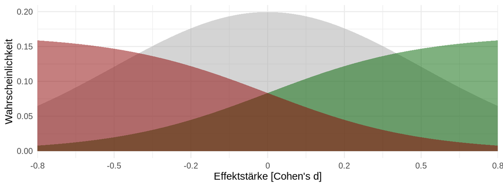

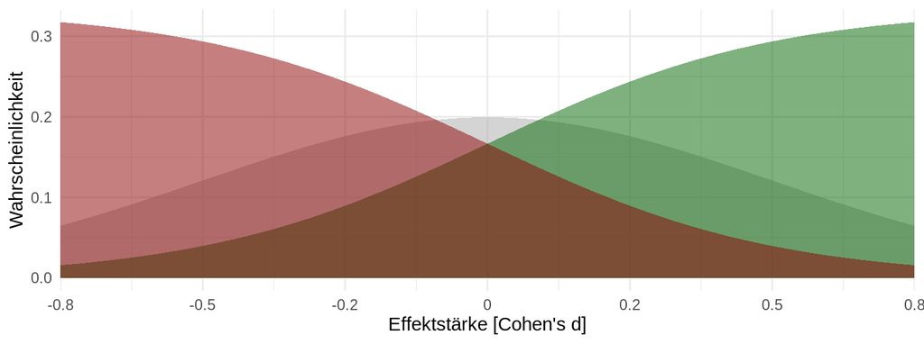